# Habits Regarding Social Media

STATS 220 Semester One 2024

Stefan Walles (swal435)

2025-07-01

[figure not shown]

## Introduction

I am not a very avid user of social media, but I recognise that this is not the case for everyone. I therefore decided to create a form to investigate people’s social media habits. I was interested to know how much time people spent on social media and what sorts of social media they used. I also recorded some information about the kind of people who answered the form, like age, interest, and personality type. I made sure to keep respondents anonymous.

I was careful about using response validation. For numeric answers I specified specific ranges. For ages I only allowed values from 12 to 120. For the number of hours spent on social media I only allowed values between 0 and 168 as there are only 168 hours in a week. I also asked people to describe their sentiment towards social media. I validated this question using a regular expression (`^[a-zA-Z]{1,16}$`) that only allowed one word of up to 16 characters. On reflection I realised I also should not have allowed upper-case letters. All other questions had fixed options for participants to choose from.

For analysing changes between weeks, I could calculate and compare the mean hours spent on social media for each week. I also asked people to rate their feelings toward social media on a 1 to 5 scale (negative to positive). This could allow me to track how people feel about social media over time. I can also track popularity across some social media platforms using the data from question 5.

Link: https://forms.gle/W83LCSFhKMKk4Y937

## Analytics

```r
# Read in the data
learning_data <- read_csv("https://docs.google.com/spreadsheets/d/e/2PACX-1vSRQQO-vbQ5MTxptDnxvM2lm94UeZt2JqBEtiw_hC0RL1ys8P1WMNdxdl4up__bGN-jfW-kh3DbTZ8D/pub?gid=363618696&single=true&output=csv")

# Rename the variables
learning_data <- learning_data %>%
  rename(
    date = 1,
    age = 2,
    interests = 3,
    personality = 4,
    sm_hours = 5,
    platforms = 6,
    sm_type = 7,
    rating = 8,
    sentiment = 9
  )
```

### Participation

**AGE**

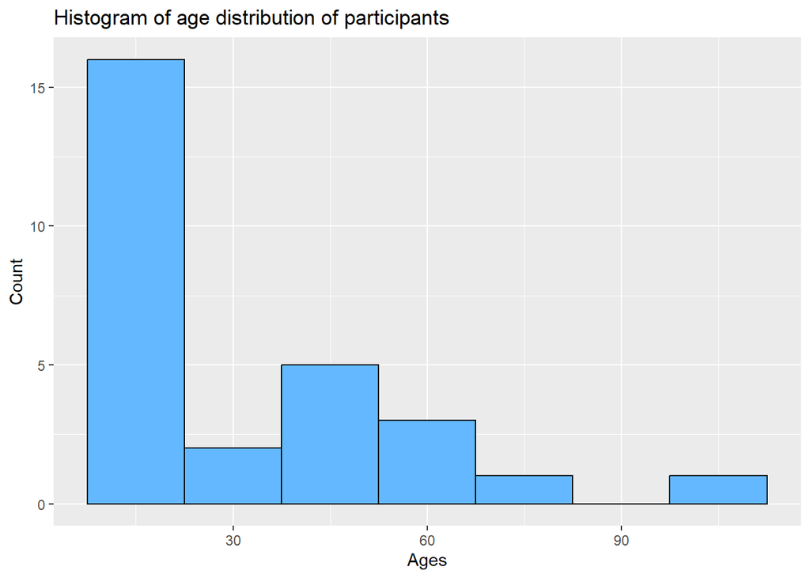

```r
# Create Histogram
learning_data %>%
  ggplot(mapping = aes(x = age)) +
  geom_histogram(binwidth = 15, fill = "steelblue1", colour = "black") +
  labs(title = "Histogram of age distribution of participants",
       x = "Ages",
       y = "Count")
```

The oldest person is 100 years old and the youngest person is 16 years old. The mean age of participants is approximately 34 years.

**Interests**

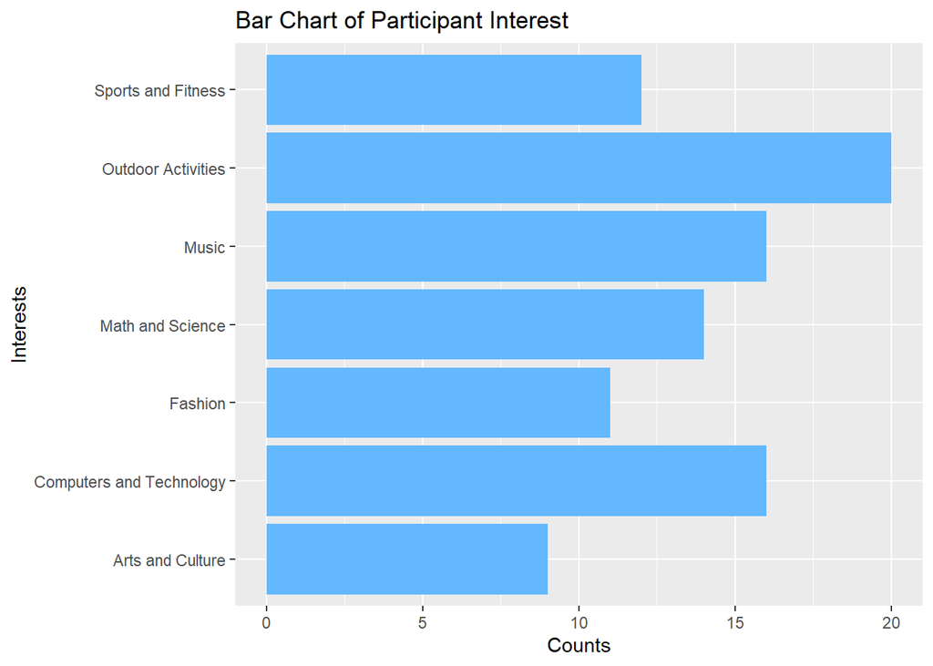

```r
# Seperate and clean data
interests <- str_split(learning_data$interests, ", ") %>%
  unlist()

interests <- interests[!(interests == "eg. Camping" |
                           interests == "Hiking" |
                           interests == "Fishing" |
                           interests == "etc.")]

# Make a bar chart
interests %>%
  as_tibble() %>%
  ggplot() +
  geom_bar(aes(y = interests), fill = "steelblue1") +
  labs(title = "Bar Chart of Participant Interest",
       y = "Interests",
       x = "Counts")
```

**Personality**

I asked people to choose between doing something fun, doing something creative, or learning something new. I then classified them as either “playful”, “creative”, or “academic” respectively.

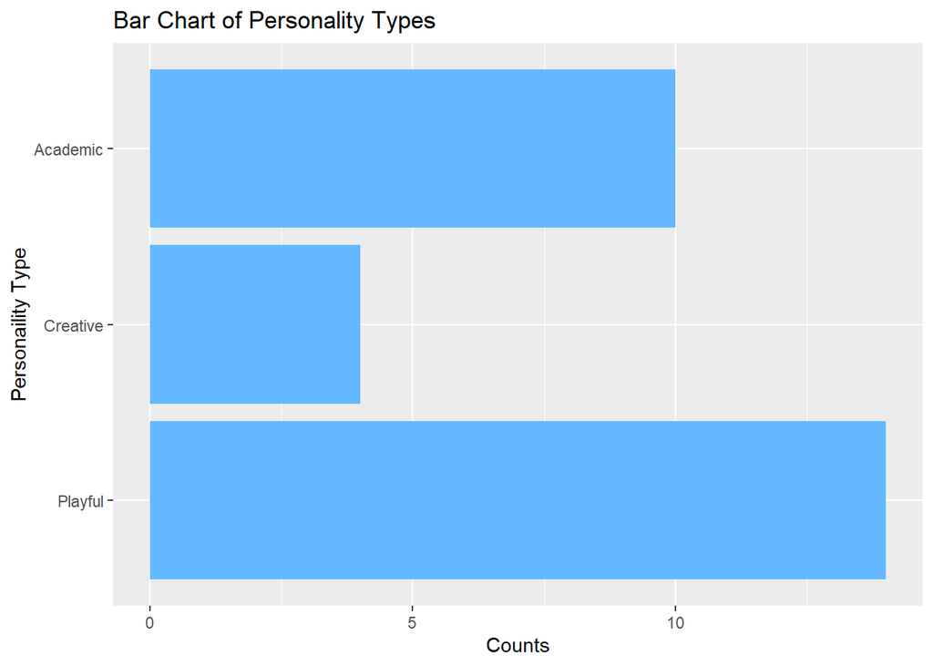

```r
# Classify and relabel data
learning_data <- learning_data %>%
  mutate(personality = factor(personality,
                              levels = c("Doing something fun",
                                         "Partaking in a creative activity",
                                         "Learning something new"),
                              labels = c("Playful", "Creative", "Academic")))

# Plot a bar chart
learning_data %>%
  ggplot() +
  geom_bar(aes(y = personality), fill = "steelblue1") +
  labs(title = "Bar Chart of Personality Types",
       y = "Personaility Type",
       x = "Counts")
```

Most people from my participants seem to prefer having fun over learning or being creative.

### Social Media Habits

**How much time do people spend on social media per week?**

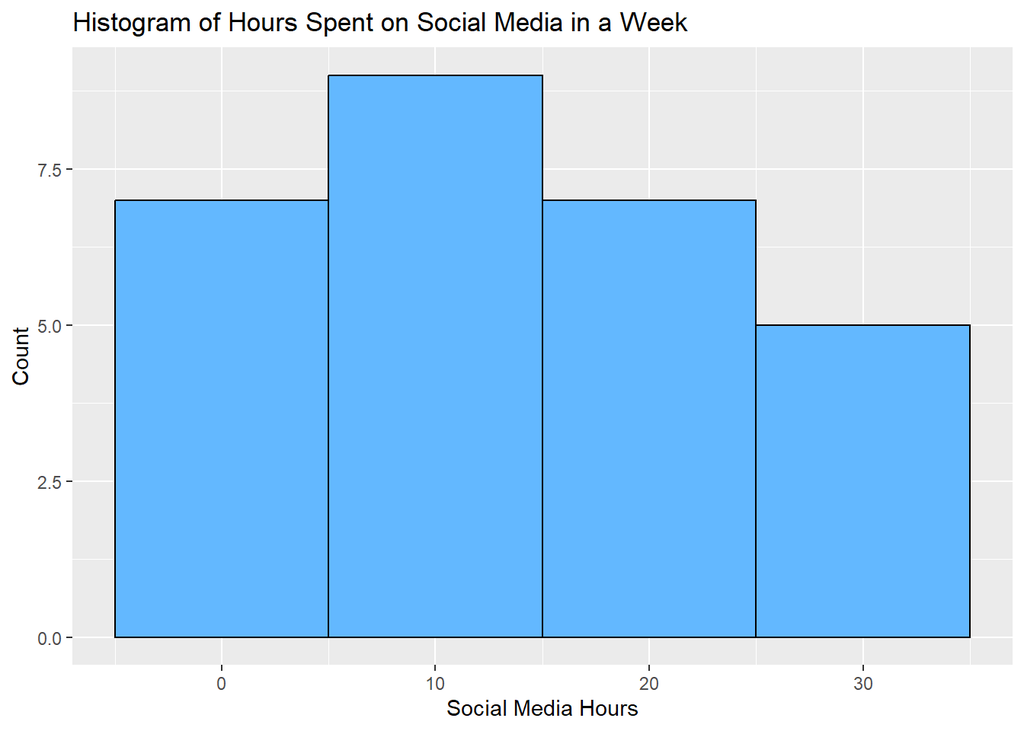

```r
# Create histogram
learning_data %>%
  ggplot(mapping = aes(x = sm_hours)) +
  geom_histogram(binwidth = 10, fill = "steelblue1", colour = "black") +
  labs(title = "Histogram of Hours Spent on Social Media in a Week",
       x = "Social Media Hours",
       y = "Count")
```

The most time spent on social media in a week is 35 hours and the least is 0 hours. The mean time spent on social media in a week is approximately 14 hours and 30 minutes.

**What kinds of social media do people prefer to use?**

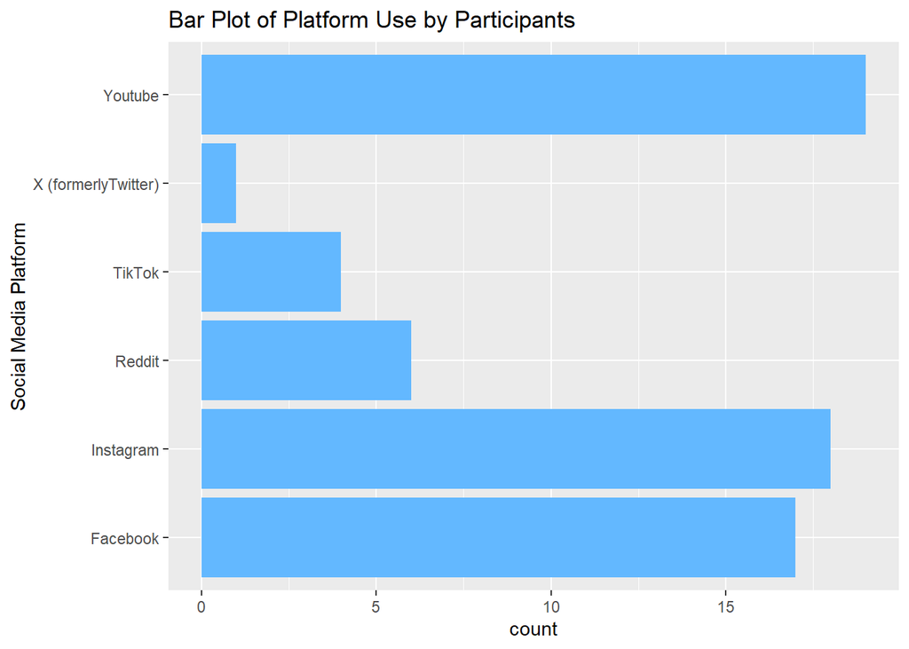

```r
#Platforms
# Seperate multiple choices by one participant
platforms <- str_split(learning_data$platforms, ", ") %>%
  unlist()

# Create bar chart
platforms %>%
  as_tibble() %>%
  ggplot() +
  geom_bar(aes(y = platforms), fill = "steelblue1") +
  labs(title = "Bar Plot of Platform Use by Participants",
       y = "Social Media Platform",
       x = "count")
```

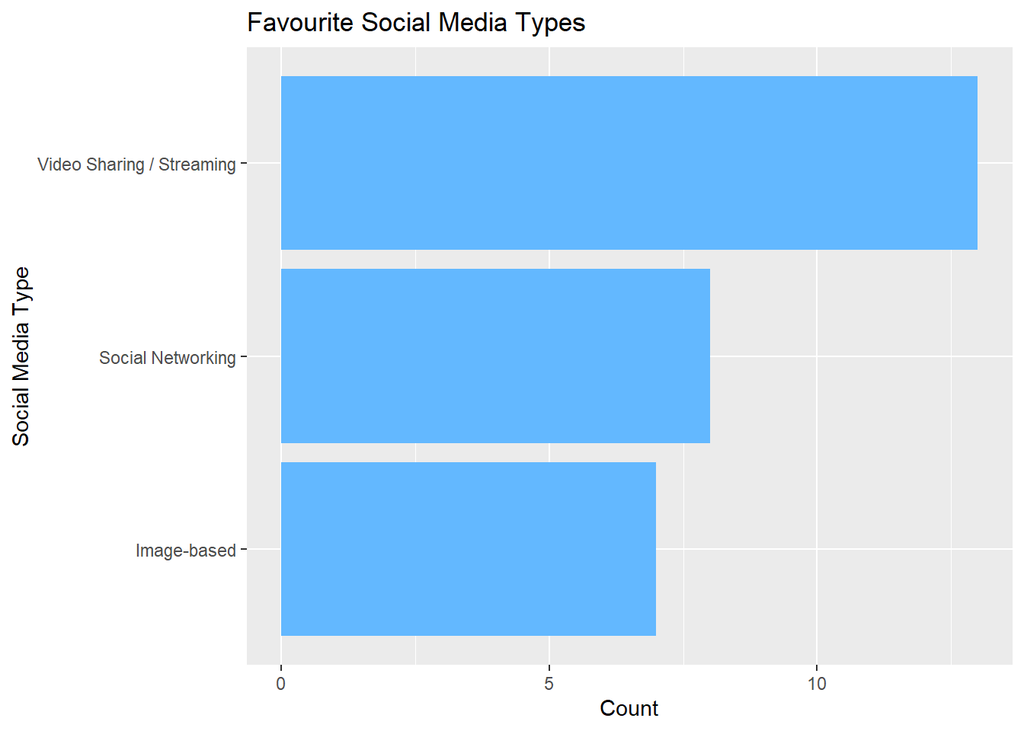

```r
# Social Media Type
# Remove the examples using code learned in STATS 380
learning_data <- learning_data %>%
  mutate(sm_type = sub(" \\(eg.+\\)$", "", sm_type))

# Craete bar chart
learning_data %>%
  ggplot() +
  geom_bar(aes(y = sm_type), fill = "steelblue1") +
  labs(title = "Favourite Social Media Types",
       y = "Social Media Type",
       x = "Count")
```

**How do people feel about social media?**

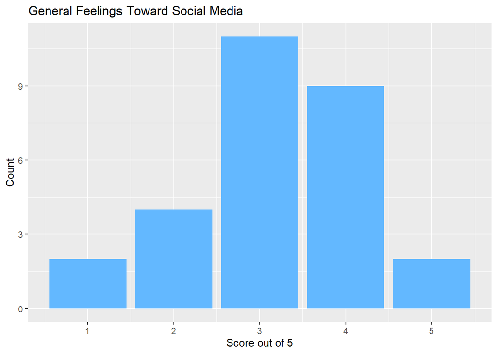

```r
# Ratings
#Create a bar chart
learning_data %>%
  ggplot() +
  geom_bar(aes(x = rating), fill = "steelblue1") +
  labs(title = "General Feelings Toward Social Media",
       x = "Score out of 5",
       y = "Count")
```

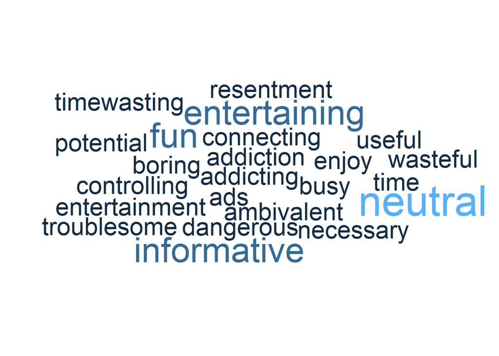

```r
# Sentiment
# Manipulate data to create a word chart using ggwordcloud
learning_data <- learning_data %>%
  mutate(sentiment = tolower(sentiment),
         sentiment_count = as.numeric(table(sentiment)[sentiment]))

# Plot a word cloud
learning_data %>%
  group_by(sentiment) %>%
  summarise(count = n()) %>%
  ggplot(aes(label = sentiment, colour = count, size = count / sum(count))) +
  geom_text_wordcloud() +
  scale_size_area(max_size = 15) +
  theme_minimal()
```

### Reflection

Most of my participants were around 15 to 20 years old. They had a variety of interests and I have classified most of them as playful.

A lot of my participants spend upwards of 10 hours a week on social media. Youtube, Instagram, and Facebook are the most popular social media platforms among my participants and they also seem too have a preference for Video Sharing / Streaming platforms.

Most of my participants have rated their feelings toward social media as 3 or better on a scale from 1 to 5. When asked to describe their sentiment towards social media I got a wide variety of responses from “entertaining” and “informative” to “addicting” and “resentment”.

## Learning Reflection

The most interesting I idea I learned about in this module was on how to create reports on data that could change as the data changes. It was really interesting for me to discover that you can use Google Forms to create a Google Sheets file that updates automatically. I also enjoyed learning about the publishing feature and using the link from that to get updated information for your report.

I believe that the guidelines we learned about for creating forms are really important for collecting accurate and useful information while ensuring that participants feel safe engaging with it. If participants feel safe and comfortable they can be more likely to give you accurate information.